# ExtraaLearn Project

Strong negative correlations can be noticed between `phone` and `email` and between `professional` and `unemployed`, respectively. This is due to the fact that these dummy variables were created to optimally categorize data points of the previous categorical variable. They are complete opposites of each other.

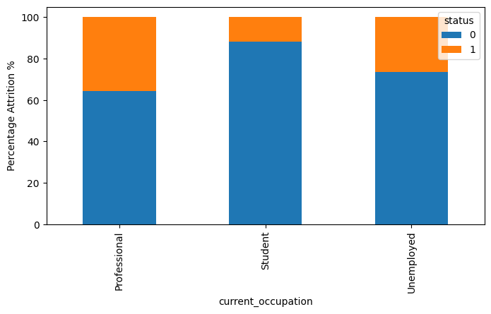

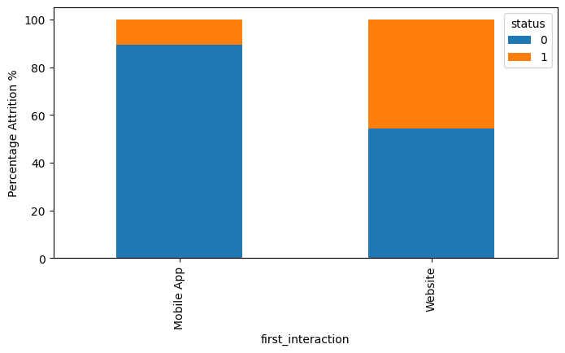

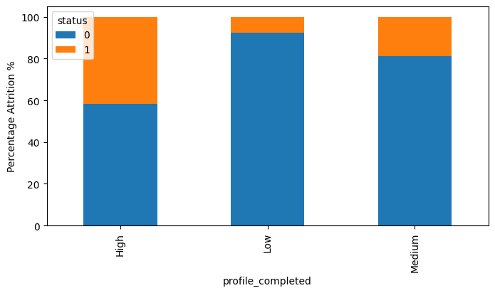

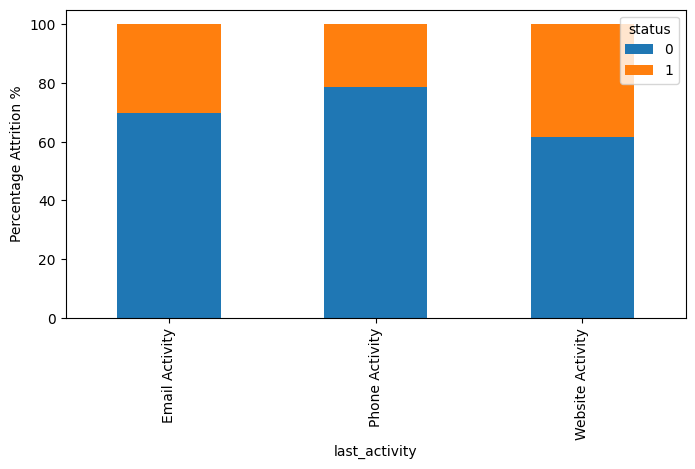

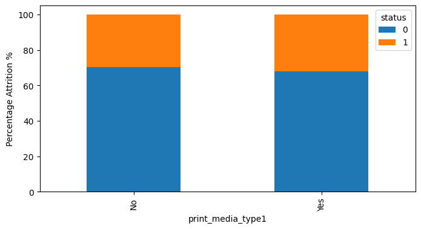

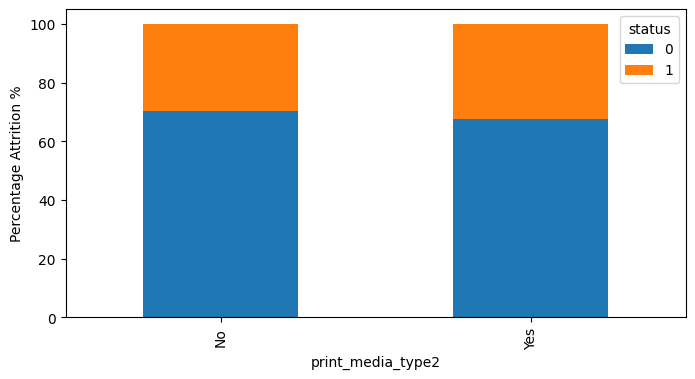

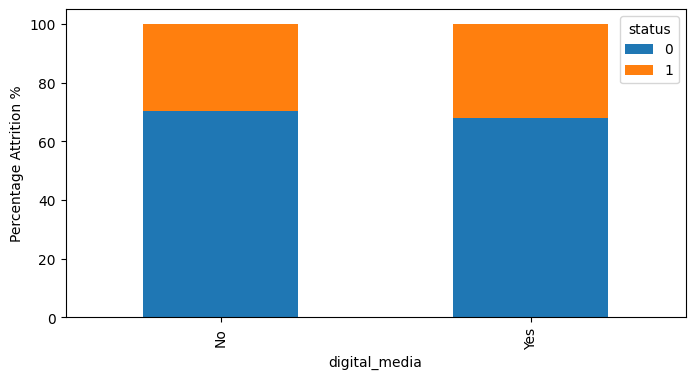

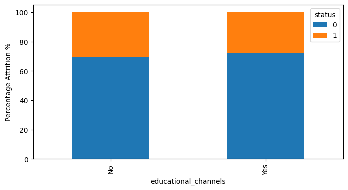

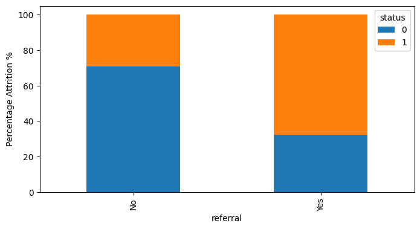

```python
# Countplots

for i in df_categorical:
    if i!='status':
        (pd.crosstab(data[i],df['status'],normalize='index')*100).plot(kind='bar',figsize=(8,4),stacked=True)
        plt.ylabel('Percentage Attrition %')
```

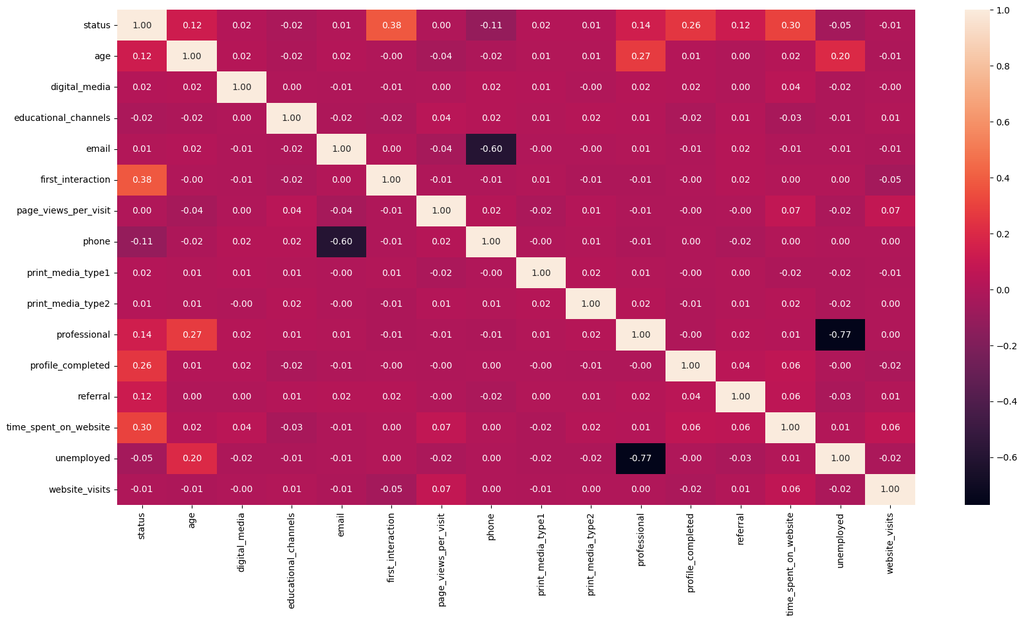

```python
# Correlation heatmap

plt.figure(figsize=(20,10))
sns.heatmap(df_clean.corr(),annot=True,fmt=".2f")
plt.show()
```

## Building a Decision Tree model

Firstly, let us divide data into two groups: our target variable `y_dt` and our independent variables `x_dt`. Then we will divide these two groups in two subsets of data, namely *train* and *test* datasets. A 80-20 split is usually a benchmark and suitable split for this case.

```python
df_final = df_clean.copy()
```

```python
x_dt = df_final.drop(["status"], axis=1)
y_dt = df_final["status"]

print('X Shape:', x_dt.shape);
print('Y Shape:', y_dt.shape);
```

```
X Shape: (4612, 15)
Y Shape: (4612,)
```

```python
x_dt_train, x_dt_test, y_dt_train, y_dt_test = train_test_split(x_dt, y_dt, test_size=0.2, random_state=1, stratify=y_dt); # stratify is useful when dealing with imbalanced datasets to ensure both the training and testing sets have representative class distributions

# Checking the shape of the Train and Test sets
print('X Train Shape:', x_dt_train.shape);
print('X Test Shape:', x_dt_test.shape);
print('Y Train Shape:', y_dt_train.shape);
print('Y Test Shape:', y_dt_test.shape);
```

```
X Train Shape: (3689, 15)
X Test Shape: (923, 15)
Y Train Shape: (3689,)
Y Test Shape: (923,)
```

Also note that for Decision Tree and Random Forest models, we do not need to scale our data, as these models are insensitive to large variance in data.

Now we continue building our decision tree (dt) model...

```python
dt = DecisionTreeClassifier(random_state=1);
dt.fit(x_dt_train, y_dt_train)
y_dt_train_pred_dt = dt.predict(x_dt_train)

print(classification_report(y_dt_train, y_dt_train_pred_dt));
```

```
              precision    recall  f1-score   support

           0       1.00      1.00      1.00      2588
           1       1.00      1.00      1.00      1101

    accuracy                           1.00      3689
   macro avg       1.00      1.00      1.00      3689
weighted avg       1.00      1.00      1.00      3689
```

```python
y_dt_test_pred_dt = dt.predict(x_dt_test)

print(classification_report(y_dt_test, y_dt_test_pred_dt));
```

```
              precision    recall  f1-score   support

           0       0.87      0.85      0.86       647
           1       0.67      0.71      0.69       276

    accuracy                           0.81       923
   macro avg       0.77      0.78      0.78       923
weighted avg       0.81      0.81      0.81       923
```

The (testing) model's performance on the test dataset appears reasonable. Based on the higher precision and recall for class 0 compared to class 1, the model seems to be doing better at predicting when leads do not become customers than when they do.

The F1-score provides a balanced view of precision and recall. The accuracy, macro average, and weighted average scores suggest that the model is making reasonably accurate predictions across both classes, considering their distribution in the dataset.

There is however room for further improvement, especially considering the fact that due to the large number of variables, the model might be overfitting.

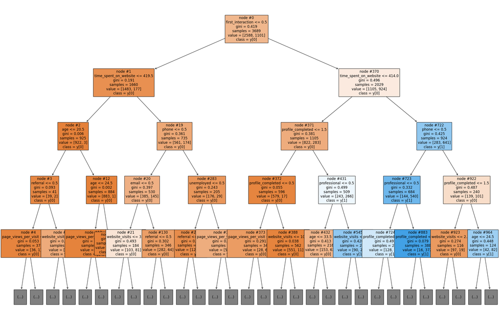

```python
features = list(x_dt.columns);
plt.figure(figsize=(30,20))
tree.plot_tree(dt, max_depth=4, feature_names=features, filled=True, fontsize=12, node_ids=True, class_names=True);
plt.show()
```

```python
importances = dt.feature_importances_
columns = x_dt.columns;
importance_df_astro = pd.DataFrame(importances, index=columns, columns=['Importance']).sort_values(by='Importance', ascending=False);

print(importance_df_astro)
```

```
                       Importance
time_spent_on_website    0.265285
first_interaction        0.144004
page_views_per_visit     0.135671
profile_completed        0.133755
age                      0.089717
professional             0.063313
website_visits           0.056852
phone                    0.037069
email                    0.026214
print_media_type2        0.009868
unemployed               0.009267
digital_media            0.008349
referral                 0.007414
educational_channels     0.006793
print_media_type1        0.006428
```

The `dt.feature_importances_` function calculates and orders all features based on their significance in predicting the value of `status`.

`time_spent_on_website` is the most important variable, whereas `first_interaction` (the second most important feature) was used as a spliter in the initial node.

## Do we need to prune the tree?

The goal of pruning is to reduce high-dimensional datasets to a few important features, based on information gain changes.

I have decided to remove the eight least important variables from the dataset, thus creating a new dataset and applying the same model.

Let us remove these variables: `email, phone, print_media_type2, unemployed, digital_media, referral, educational_channels, print_media_type1`; and see what happens to our model...

```python
x_dt_2 = x_dt.drop(["email", "phone", "print_media_type2", "unemployed", "digital_media", "referral", "educational_channels", "print_media_type1"], axis=1)
```

```python
x_dt_2.shape
```

```
(4612, 7)
```

```python
x_dt_2_train, x_dt_2_test, y_dt_train, y_dt_test = train_test_split(x_dt_2, y_dt, test_size=0.2, random_state=1, stratify=y_dt);

# Checking the shape of the Train and Test sets
print('X Train Shape:', x_dt_2_train.shape);
print('X Test Shape:', x_dt_2_test.shape);
print('Y Train Shape:', y_dt_train.shape);
print('Y Test Shape:', y_dt_test.shape);
```

```
X Train Shape: (3689, 7)
X Test Shape: (923, 7)
Y Train Shape: (3689,)
Y Test Shape: (923,)
```

```python
dt.fit(x_dt_2_train, y_dt_train)
y_dt_2_train_pred_dt = dt.predict(x_dt_2_train)

print(classification_report(y_dt_train, y_dt_2_train_pred_dt));
```

```
              precision    recall  f1-score   support

           0       1.00      1.00      1.00      2588
           1       1.00      1.00      1.00      1101

    accuracy                           1.00      3689
   macro avg       1.00      1.00      1.00      3689
weighted avg       1.00      1.00      1.00      3689
```

```python
y_dt_2_test_pred_dt = dt.predict(x_dt_2_test)

print(classification_report(y_dt_test, y_dt_2_test_pred_dt));
```

```
              precision    recall  f1-score   support

           0       0.85      0.82      0.84       647
           1       0.62      0.67      0.64       276

    accuracy                           0.78       923
   macro avg       0.74      0.75      0.74       923
weighted avg       0.78      0.78      0.78       923
```

The model's performance worsens when features are removed.

Here are the two side-by-side:

```python
print("DT model with 15 features:")
print(classification_report(y_dt_test, y_dt_test_pred_dt));
print('-' * 55)
print("DT model with 7 features:")
print(classification_report(y_dt_test, y_dt_2_test_pred_dt));
```

```
DT model with 15 features:
              precision    recall  f1-score   support

           0       0.87      0.85      0.86       647
           1       0.67      0.71      0.69       276

    accuracy                           0.81       923
   macro avg       0.77      0.78      0.78       923
weighted avg       0.81      0.81      0.81       923

-------------------------------------------------------
DT model with 7 features:
              precision    recall  f1-score   support

           0       0.85      0.82      0.84       647
           1       0.62      0.67      0.64       276

    accuracy                           0.78       923
   macro avg       0.74      0.75      0.74       923
weighted avg       0.78      0.78      0.78       923
```

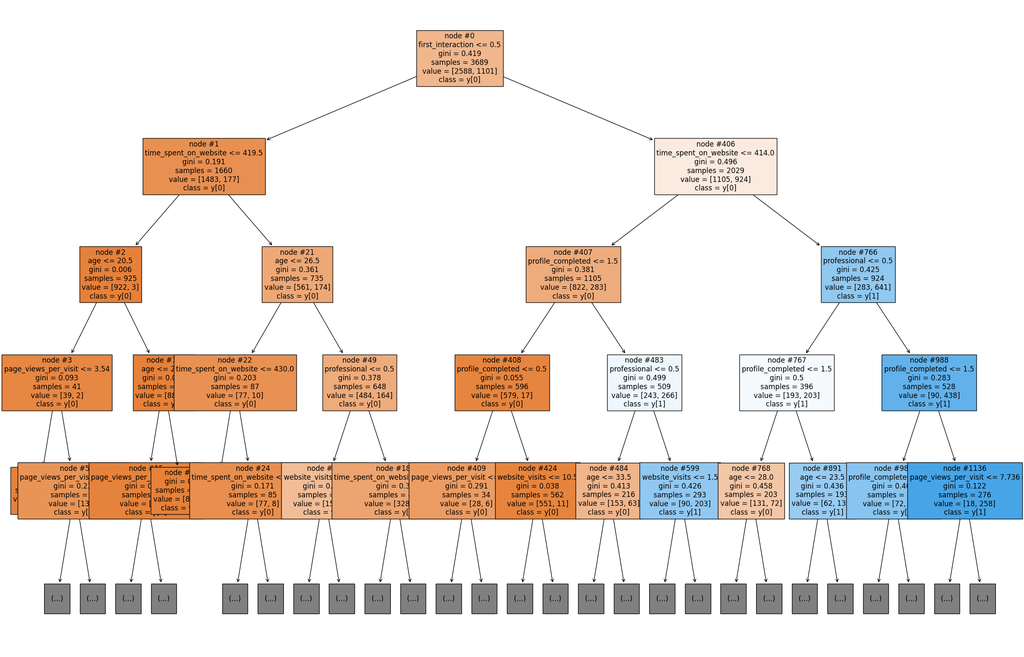

```python
features = list(x_dt_2.columns);
plt.figure(figsize=(30,20))
tree.plot_tree(dt, max_depth=4, feature_names=features, filled=True, fontsize=12, node_ids=True, class_names=True);
plt.show()
```

```python
importances = dt.feature_importances_
columns2 = x_dt_2.columns;
importance_df_2_astro = pd.DataFrame(importances, index=columns2, columns=['Importance']).sort_values(by='Importance', ascending=False);

print(importance_df_2_astro)
```

```
                       Importance
time_spent_on_website    0.334515
page_views_per_visit     0.147924
first_interaction        0.144144
age                      0.123914
profile_completed        0.120851
website_visits           0.071201
professional             0.057452
```

The role of `time_spent_on_website` and `first_interaction` do not change much in the new decision tree.

Importance does not change much either compared to each of the variable's relative weight in the previous dataset.

## Building a Random Forest model

With the same reasoning behind the previous models, let use both subsets of features: `x_dt` and `x_dt_2` to build two random forest (rf) models

```python
rf = RandomForestClassifier(class_weight = {0: 0.17, 1: 0.83}, random_state = 1)

rf.fit(x_dt_train, y_dt_train)
rf.fit(x_dt_test, y_dt_test)
```

```
RandomForestClassifier(class_weight={0: 0.17, 1: 0.83}, random_state=1)
```

```python
y_pred_train_rf = rf.predict(x_dt_train)
y_pred_test_rf = rf.predict(x_dt_test)

print(classification_report(y_dt_train, y_pred_train_rf))
print(classification_report(y_dt_test, y_pred_test_rf));
```

```
              precision    recall  f1-score   support

           0       0.86      0.93      0.89      2588
           1       0.79      0.65      0.72      1101

    accuracy                           0.85      3689
   macro avg       0.83      0.79      0.81      3689
weighted avg       0.84      0.85      0.84      3689

              precision    recall  f1-score   support

           0       1.00      1.00      1.00       647
           1       1.00      1.00      1.00       276

    accuracy                           1.00       923
   macro avg       1.00      1.00      1.00       923
weighted avg       1.00      1.00      1.00       923
```

## Do we need to prune the tree?

```python
rf.fit(x_dt_2_train, y_dt_train)
rf.fit(x_dt_2_test, y_dt_test)
```

```
RandomForestClassifier(class_weight={0: 0.17, 1: 0.83}, random_state=1)
```

```python
y_pred_train_rf_2 = rf.predict(x_dt_2_train)
y_pred_test_rf_2 = rf.predict(x_dt_2_test)

print(classification_report(y_dt_train, y_pred_train_rf_2))
print(classification_report(y_dt_test, y_pred_test_rf_2));
```

```
              precision    recall  f1-score   support

           0       0.85      0.90      0.88      2588
           1       0.73      0.63      0.68      1101

    accuracy                           0.82      3689
   macro avg       0.79      0.77      0.78      3689
weighted avg       0.82      0.82      0.82      3689

              precision    recall  f1-score   support

           0       1.00      1.00      1.00       647
           1       1.00      1.00      1.00       276

    accuracy                           1.00       923
   macro avg       1.00      1.00      1.00       923
weighted avg       1.00      1.00      1.00       923
```

Our results show that even though we have removed features in order to reduce potential overfitting, the model's predictive prowess has fallen. There seems to be a trade off here.

Here are the two models side-by-side:

```python
print("RF model with 15 features:")
print()
print(classification_report(y_dt_train, y_pred_train_rf))
print('-' * 55)
print("RF model with 7 features:")
print()
print(classification_report(y_dt_train, y_pred_train_rf_2))
```

```
RF model with 15 features:

              precision    recall  f1-score   support

           0       0.86      0.93      0.89      2588
           1       0.79      0.65      0.72      1101

    accuracy                           0.85      3689
   macro avg       0.83      0.79      0.81      3689
weighted avg       0.84      0.85      0.84      3689

-------------------------------------------------------
RF model with 7 features:

              precision    recall  f1-score   support

           0       0.85      0.90      0.88      2588
           1       0.73      0.63      0.68      1101

    accuracy                           0.82      3689
   macro avg       0.79      0.77      0.78      3689
weighted avg       0.82      0.82      0.82      3689
```

## Actionable Insights and Recommendations

**Questions**

1. Leads will have different expectations from the outcome of the course and the current occupation may play a key role in getting them to participate in the program. Find out how current occupation affects lead status.
2. The company's first impression on the customer must have an impact. Do the first channels of interaction have an impact on the lead status?
3. The company uses multiple modes to interact with prospects. Which way of interaction works best?
4. The company gets leads from various channels such as print media, digital media, referrals, etc. Which of these channels have the highest lead conversion rate?
5. People browsing the website or mobile application are generally required to create a profile by sharing their personal data before they can access additional information.Does having more details about a prospect increase the chances of conversion?

# Conclusions